# Descriptive Analysis of Static Data

Maria Gordillo-Maranon

2018-03-06

> **Key Points**

> New defined **cohort** of study as participants following Johnson et al (2017) exclusion criteria and removing patients: (i) who had been >1 times in ICU, (ii) who had >1 records of hospital admission, (iii) > 89 years old. The new cohort included **36,227 patients**.

> Categorisation of BMI (`bmi_cat`), service of admission (`service_cat`) and ethnicity (`race_cat`).

> The descriptive and independence analysis (**Chi-squared test**) between categorical static variables and mortality suggested that ethnicity (*P*< 2.2e-16), service of admission (*P*< 2.2e-16), BMI (*P*=2.662e-16), and gender (*P*=0.002) were associated with mortality.

> Interestingly, the proportion of **cardiac surgery** patients who died in ICU was lower compared to other patients (1.9%), being **neurological medical** the higher percentage (13.5%). **Hispanic** showed to have a lower proportion of deaths in ICU, and patients with a **BMI >25** are less likely to die.

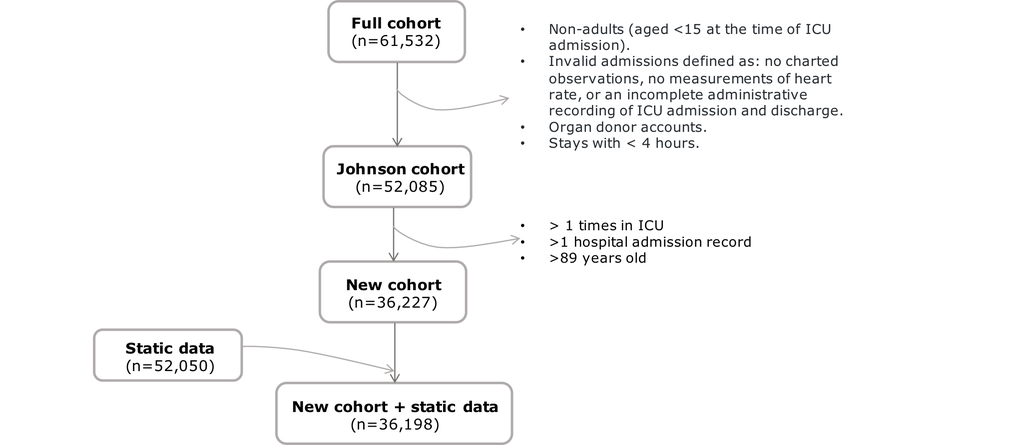

```r
rm(list = ls())
library(data.table) # For fast loading and pre-processing of large datasets
packageVersion("data.table")
```

## Data preparation

It is done as shown [here](https://github.com/catavallejos/Maria/blob/master/Initial%20resources/PreProcMIMICIII.Rmd).

```r
# Reading the expression counts
olddir <- getwd()
setwd(data.path)

Cohort <- fread(input = 'zcat < df_cohort.csv.gz')
Df <- fread(input = 'zcat < df_data.csv.gz')
Dfstatic <- fread(input = 'zcat < df_static_data.csv.gz')
Dfcensor <- fread(input = 'zcat < df_censor.csv.gz')
Dfdeath <- fread(input = 'zcat < df_death.csv.gz')

# We can extract death from here
setwd(olddir)
```

## Defining the cohort

In addition to Johnson et al (2017) exclusion criteria, we extended the exclusion criteria as follows:

- Remove patients who had been >1 times in ICU.
- Remove patients who had >1 records of hospital admission.
- Remove patients >89 years old. Patients who are older than 89 years old at any time in the database have had their date of birth shifted to obscure their age and comply with HIPAA. The shift process was as follows: the patient’s age at their first admission was determined. The date of birth was then set to exactly 300 years before their first admission.

```r
JohnsonCohort <- subset(Cohort,
                 subset = (exclusion_over_15 == 0) &
                   (exclusion_valid_data == 0) &
                   (exclusion_stay_lt_4hr == 0) &
                   (exclusion_organ_donor == 0))

dim(JohnsonCohort)

# Select the ones that are not duplicated

NewCohort <- JohnsonCohort[(!duplicated(JohnsonCohort$subject_id) & age<89),c("subject_id","hadm_id","icustay_id","intime", "outtime", "age","gender", "ethnicity", "icu_los", "hosp_los","death_icu") ]

# Number of patients >89 (removed)
nrow(JohnsonCohort[(!duplicated(JohnsonCohort$subject_id) & age>89)])

dim(NewCohort)
```

After applying the additional criteria, the cohort reduces from 52085 patients to 36227 (1960 were >89 yo). The new dataset contains information for 11 variables instead of 61: `subject_id`, `hadm_id`, `icustay_id`, `intime`, `outtime`, `age`, `gender`, `ethnicity`, `icu_los`, `hosp_los`, `death_icu`.

The static data is merged with the general information using the `icustay_id`. This process results in a 36198 patients with 41 associated variables.

```r
NewCohort_static<- merge(NewCohort, Dfstatic, by = "icustay_id")
dim(NewCohort_static)
```

```r
names(NewCohort_static)
```

It can be seen that 29 patients did not have static data. These are stored in `MissingStaticsDF`.

```r
nrow(NewCohort_static[subject_id.x==subject_id.y])
nrow(NewCohort_static[hadm_id.x==hadm_id.y])

# Number of patients in the full data (NewCohort) who did not have static data
length(unique(NewCohort_static$icustay_id))
length(unique(NewCohort$icustay_id))

# Which ones have been missed in the analysis
missing_statics <- setdiff(sort(unique(NewCohort$icustay_id)), sort(unique(NewCohort_static$icustay_id)))

MissingStaticsDF = list()
for(ele in missing_statics){
  MissingStaticsDF <- rbind(MissingStaticsDF, NewCohort[icustay_id==ele])
}
```

## Participant characteristics

|  | All (n=36198) | Died in ICU (n=3168) | Did not die in ICU (n=33030) |
| --- | --- | --- | --- |
| Age-years(mean+sd) | 62.5 ± 16.9 | 68.1 ± 15.1 | 61.9 ± 17.0 |
| Age-years(median) | 64.5 | 71.0 | 63.9 |
| Gender (% male) | 20916 (57.8%) | 1748 (8.4%) | 19168 (91.6%) |
| Gender (% female) | 15282 (42.2%) | 1420 (9.3%) | 13862 (90.7%) |
| Height | 170.4 ± 14.2 (n=15055) | 168.1 ± 11.4 (n=1109) | 170.6 ± 14.4 (n=13946) |
| Weight | 81.7 ± 23.8 (n=31593) | 78.9 ± 23.6 (n=2820) | 81.9 ± 23.8 (n=28773) |
| BMI | 28.5 ± 7.2 (n=15003) | 27.9 ± 7.2 (n=1103) | 28.5 ± 7.0 (n=13900) |
| **Ethnicity** |  |  |  |
| Asian | 2.4% | 9.6% | 90.4% |
| Black | 7.8% | 7.7% | 92.3% |
| Hispanic | 3.4% | 5.3% | 94.7% |
| White | 70.8% | 8.2% | 91.8% |
| Other | 15.5% | 12.3% | 87.7% |
| **Service** |  |  |  |
| Medical - general service for internal medicine (% admissions) | 36.0% | 11.7% | 88.3% |
| Cardiac Medical- for non-surgical cardiac related admissions (% admissions) | 16.0% | 6.5% | 93.5% |
| Orthopaedic medicine - non-surgical, relating to musculoskeletal system (% admissions) | 1.9% | 20.9% | 79.1% |
| Neurologic Medical - non-surgical, relating to the brain (% admissions) | 5.0% | 13.5% | 86.5% |
| Neurologic Surgical - surgical, relating to the brain (% admissions) | 7.2% | 8.8% | 91.2% |
| Thoracic Surgical - surgery on the thorax, located between the neck and the abdomen (% admissions) | 2.2% | 6.5% | 93.5% |
| Cardiac Surgery - for surgical cardiac admissions (% admissions) | 11.7% | 1.9% | 98.1% |
| Vascular Surgical - surgery relating to the circulatory system (% admissions) | 1.9% | 11.9% | 88.1% |
| Orthopaedic - surgical, relating to the musculoskeletal system (% admissions) | 1.3% | 3.4% | 96.6% |
| Plastic - restortation/reconstruction of the human body (including cosmetic or aesthetic) (% admissions) | 0.4% | 1.4% | 98.6% |
| Surgical - general surgical service not classified elsewhere (% admissions) | 7.5% | 7.9% | 92.1% |
| Genitourinary - reproductive organs/urinary system (% admissions) | 0.7% | 1.6% | 98.4% |
| Gynecological - female reproductive systems and breasts (% admissions) | 0.5% | 3.5% | 96.5% |
| Trauma - injury or damage caused by physical harm from an external source (% admissions) | 7.3% | 7.5% | 92.5% |
| Ear, nose, and throat - conditions primarily affecting these areas (% admissions) | 0.4% | 1.5% | 98.5% |

```r
#hist(NewCohort_static$age.x, main="Age distribution in the full sample", ylab="Frequency", xlab="Age")
```

```r
#hist(NewCohort_static[death_icu==1,]$age.x, main="Age distribution in those who died in ICU", ylab="Frequency", xlab="Age")
#hist(NewCohort_static[death_icu==0,]$age.x, main="Age distribution in those who did not die in ICU", ylab="Frequency", xlab="Age")
```

```r
# Number participants
nrow(NewCohort_static[death_icu==1,])
nrow(NewCohort_static[death_icu==0,])
nrow(NewCohort_static)

# Age
mean(NewCohort_static$age.x)
sd(NewCohort_static$age.x)
mean(NewCohort_static[death_icu==1,]$age.x)
sd(NewCohort_static[death_icu==1,]$age.x)
mean(NewCohort_static[death_icu==0,]$age.x)
sd(NewCohort_static[death_icu==0,]$age.x)

median(NewCohort_static$age.x)
median(NewCohort_static[death_icu==1,]$age.x)
median(NewCohort_static[death_icu==0,]$age.x)

# Gender
nrow(NewCohort_static[is_male==1,])
nrow(NewCohort_static[is_male==1,])/nrow(NewCohort_static)
nrow(NewCohort_static[(death_icu==1 &is_male==1),])
nrow(NewCohort_static[(death_icu==1 & is_male==1),])/nrow(NewCohort_static[is_male==1,])*100
nrow(NewCohort_static[(death_icu==0 &is_male==1),])
nrow(NewCohort_static[(death_icu==0 & is_male==1),])/nrow(NewCohort_static[is_male==1,])*100

nrow(NewCohort_static[is_male==0,])
nrow(NewCohort_static[is_male==0,])/nrow(NewCohort_static)
nrow(NewCohort_static[(death_icu==1 &is_male==0),])
nrow(NewCohort_static[(death_icu==1 & is_male==0),])/nrow(NewCohort_static[is_male==0,])*100
nrow(NewCohort_static[(death_icu==0 &is_male==0),])
nrow(NewCohort_static[(death_icu==0 & is_male==0),])/nrow(NewCohort_static[is_male==0,])*100

# Height
# 22593 NAs nrow(NewCohort_static[is.na(height),]) -> 59%
nrow(NewCohort_static[(!is.na(height)),])
mean(NewCohort_static[(!is.na(height)),]$height)
sd(NewCohort_static[(!is.na(height)),]$height)
# 2273 nrow(NewCohort_static[(death_icu==1 & is.na(height)),]) -> 66%
nrow(NewCohort_static[(death_icu==1 & !is.na(height)),])
mean(NewCohort_static[(death_icu==1 & !is.na(height)),]$height)
sd(NewCohort_static[(death_icu==1 & !is.na(height)),]$height)
# 20320 NAs nrow(NewCohort_static[(death_icu==0 & is.na(height)),]) -> 58%
nrow(NewCohort_static[(death_icu==0 & !is.na(height)),])
mean(NewCohort_static[(death_icu==0 & !is.na(height)),]$height)
sd(NewCohort_static[(death_icu==0 & !is.na(height)),]$height)

# Weight
# 22593 NAs nrow(NewCohort_static[is.na(height),]) -> 59%
nrow(NewCohort_static[(!is.na(weight)),])
mean(NewCohort_static[(!is.na(weight)),]$weight)
sd(NewCohort_static[(!is.na(weight)),]$weight)
# 2273 nrow(NewCohort_static[(death_icu==1 & is.na(height)),]) -> 66%
nrow(NewCohort_static[(death_icu==1 & !is.na(weight)),])
mean(NewCohort_static[(death_icu==1 & !is.na(weight)),]$weight)
sd(NewCohort_static[(death_icu==1 & !is.na(weight)),]$weight)
# 20320 NAs nrow(NewCohort_static[(death_icu==0 & is.na(height)),]) -> 58%
nrow(NewCohort_static[(death_icu==0 & !is.na(weight)),])
mean(NewCohort_static[(death_icu==0 & !is.na(weight)),]$weight)
sd(NewCohort_static[(death_icu==0 & !is.na(weight)),]$weight)


# BMI
# 22647 NAs nrow(NewCohort_static[is.na(bmi),]) -> 59%
nrow(NewCohort_static[(!is.na(bmi)),])
mean(NewCohort_static[(!is.na(bmi)),]$bmi)
sd(NewCohort_static[(!is.na(bmi)),]$bmi)
# 2279 nrow(NewCohort_static[(death_icu==1 & is.na(bmi)),]) -> 66%
nrow(NewCohort_static[(death_icu==1 & !is.na(bmi)),])
mean(NewCohort_static[(death_icu==1 & !is.na(bmi)),]$bmi)
sd(NewCohort_static[(death_icu==1 & !is.na(bmi)),]$bmi)
# 20368 NAs nrow(NewCohort_static[(death_icu==0 & is.na(bmi)),]) -> 58%
nrow(NewCohort_static[(death_icu==0 & !is.na(bmi)),])
mean(NewCohort_static[(death_icu==0 & !is.na(bmi)),]$bmi)
sd(NewCohort_static[(death_icu==0 & !is.na(bmi)),]$bmi)

#Services
nrow(NewCohort_static[service_med==1,])/nrow(NewCohort_static)*100
nrow(NewCohort_static[service_cmed==1,])/nrow(NewCohort_static)*100
nrow(NewCohort_static[service_omed==1,])/nrow(NewCohort_static)*100
nrow(NewCohort_static[service_nmed==1,])/nrow(NewCohort_static)*100
nrow(NewCohort_static[service_nsurg==1,])/nrow(NewCohort_static)*100
nrow(NewCohort_static[service_tsurg==1,])/nrow(NewCohort_static)*100
nrow(NewCohort_static[service_csurg==1,])/nrow(NewCohort_static)*100
nrow(NewCohort_static[service_vsurg==1,])/nrow(NewCohort_static)*100
nrow(NewCohort_static[service_ortho==1,])/nrow(NewCohort_static)*100
nrow(NewCohort_static[service_psurg==1,])/nrow(NewCohort_static)*100
nrow(NewCohort_static[service_surg==1,])/nrow(NewCohort_static)*100
nrow(NewCohort_static[service_gu==1,])/nrow(NewCohort_static)*100
nrow(NewCohort_static[service_gyn==1,])/nrow(NewCohort_static)*100
nrow(NewCohort_static[service_traum==1,])/nrow(NewCohort_static)*100
nrow(NewCohort_static[service_ent==1,])/nrow(NewCohort_static)*100
nrow(NewCohort_static[emergency_admission==1,])/nrow(NewCohort_static)*100

nrow(NewCohort_static[(death_icu==1 & service_med==1),])/nrow(NewCohort_static[service_med==1,])*100
nrow(NewCohort_static[(death_icu==1 & service_cmed==1),])/nrow(NewCohort_static[service_cmed==1,])*100
nrow(NewCohort_static[(death_icu==1 & service_omed==1),])/nrow(NewCohort_static[service_omed==1,])*100
nrow(NewCohort_static[(death_icu==1 & service_nmed==1),])/nrow(NewCohort_static[service_nmed==1,])*100
nrow(NewCohort_static[(death_icu==1 & service_nsurg==1),])/nrow(NewCohort_static[service_nsurg==1,])*100
nrow(NewCohort_static[(death_icu==1 & service_tsurg==1),])/nrow(NewCohort_static[service_tsurg==1,])*100
nrow(NewCohort_static[(death_icu==1 & service_csurg==1),])/nrow(NewCohort_static[service_csurg==1,])*100
nrow(NewCohort_static[(death_icu==1 & service_vsurg==1),])/nrow(NewCohort_static[service_vsurg==1,])*100
nrow(NewCohort_static[(death_icu==1 & service_ortho==1),])/nrow(NewCohort_static[service_ortho==1,])*100
nrow(NewCohort_static[(death_icu==1 & service_psurg==1),])/nrow(NewCohort_static[service_psurg==1,])*100
nrow(NewCohort_static[(death_icu==1 & service_surg==1),])/nrow(NewCohort_static[service_surg==1,])*100
nrow(NewCohort_static[(death_icu==1 & service_gu==1),])/nrow(NewCohort_static[service_gu==1,])*100
nrow(NewCohort_static[(death_icu==1 & service_gyn==1),])/nrow(NewCohort_static[service_gyn==1,])*100
nrow(NewCohort_static[(death_icu==1 & service_traum==1),])/nrow(NewCohort_static[service_traum==1,])*100
nrow(NewCohort_static[(death_icu==1 & service_ent==1),])/nrow(NewCohort_static[service_ent==1,])*100
nrow(NewCohort_static[(death_icu==1 & emergency_admission==1),])/nrow(NewCohort_static[service_ent==1,])*100

nrow(NewCohort_static[(death_icu==0 & service_med==1),])/nrow(NewCohort_static[service_med==1,])*100
nrow(NewCohort_static[(death_icu==0 & service_cmed==1),])/nrow(NewCohort_static[service_cmed==1,])*100
nrow(NewCohort_static[(death_icu==0 & service_omed==1),])/nrow(NewCohort_static[service_omed==1,])*100
nrow(NewCohort_static[(death_icu==0 & service_nmed==1),])/nrow(NewCohort_static[service_nmed==1,])*100
nrow(NewCohort_static[(death_icu==0 & service_nsurg==1),])/nrow(NewCohort_static[service_nsurg==1,])*100
nrow(NewCohort_static[(death_icu==0 & service_tsurg==1),])/nrow(NewCohort_static[service_tsurg==1,])*100
nrow(NewCohort_static[(death_icu==0 & service_csurg==1),])/nrow(NewCohort_static[service_csurg==1,])*100
nrow(NewCohort_static[(death_icu==0 & service_vsurg==1),])/nrow(NewCohort_static[service_vsurg==1,])*100
nrow(NewCohort_static[(death_icu==0 & service_ortho==1),])/nrow(NewCohort_static[service_ortho==1,])*100
nrow(NewCohort_static[(death_icu==0 & service_psurg==1),])/nrow(NewCohort_static[service_psurg==1,])*100
nrow(NewCohort_static[(death_icu==0 & service_surg==1),])/nrow(NewCohort_static[service_surg==1,])*100
nrow(NewCohort_static[(death_icu==0 & service_gu==1),])/nrow(NewCohort_static[service_gu==1,])*100
nrow(NewCohort_static[(death_icu==0 & service_gyn==1),])/nrow(NewCohort_static[service_gyn==1,])*100
nrow(NewCohort_static[(death_icu==0 & service_traum==1),])/nrow(NewCohort_static[service_traum==1,])*100
nrow(NewCohort_static[(death_icu==0 & service_ent==1),])/nrow(NewCohort_static[service_ent==1,])*100
nrow(NewCohort_static[(death_icu==0 & emergency_admission==1),])/nrow(NewCohort_static[service_ent==1,])*100
```

```r
# Check WHITE are not reported as race_asian, race_black, race_hispanic, race_other ethnicities
table(NewCohort_static$ethnicity, NewCohort_static$race_asian)
table(NewCohort_static$ethnicity, NewCohort_static$race_black)
table(NewCohort_static$ethnicity, NewCohort_static$race_hispanic)
table(NewCohort_static$ethnicity, NewCohort_static$race_other)
#Create a variable for white race
NewCohort_static[race_asian==0 & race_black==0 & race_hispanic==0 & race_other==0, race_white:=1]

#
nrow(NewCohort_static[race_asian==1,])/nrow(NewCohort_static)*100
nrow(NewCohort_static[race_black==1,])/nrow(NewCohort_static)*100
nrow(NewCohort_static[race_hispanic==1,])/nrow(NewCohort_static)*100
nrow(NewCohort_static[race_other==1,])/nrow(NewCohort_static)*100
nrow(NewCohort_static[(race_asian==0 & race_black==0 & race_hispanic==0 & race_other==0),])/nrow(NewCohort_static)*100

#
nrow(NewCohort_static[(death_icu==0 & race_asian==1),])/nrow(NewCohort_static[race_asian==1,])*100
nrow(NewCohort_static[(death_icu==1 & race_asian==1),])/nrow(NewCohort_static[race_asian==1,])*100

nrow(NewCohort_static[(death_icu==0 & race_black==1),])/nrow(NewCohort_static[race_black==1,])*100
nrow(NewCohort_static[(death_icu==1 & race_black==1),])/nrow(NewCohort_static[race_black==1,])*100

nrow(NewCohort_static[(death_icu==0 & race_hispanic==1),])/nrow(NewCohort_static[race_hispanic==1,])*100
nrow(NewCohort_static[(death_icu==1 & race_hispanic==1),])/nrow(NewCohort_static[race_hispanic==1,])*100

nrow(NewCohort_static[(death_icu==0 & race_white==1),])/nrow(NewCohort_static[race_white==1,])*100
nrow(NewCohort_static[(death_icu==1 & race_white==1),])/nrow(NewCohort_static[race_white==1,])*100

nrow(NewCohort_static[(death_icu==0 & race_other==1),])/nrow(NewCohort_static[race_other==1,])*100
nrow(NewCohort_static[(death_icu==1 & race_other==1),])/nrow(NewCohort_static[race_other==1,])*100

# New race category

NewCohort_static[race_asian==1, race_cat:= "Asian"]
NewCohort_static[race_black==1, race_cat:= "Black"]
NewCohort_static[race_hispanic==1, race_cat:= "Hispanic"]
NewCohort_static[race_white==1, race_cat:= "White"]
NewCohort_static[race_other==1, race_cat:= "Other"]
```

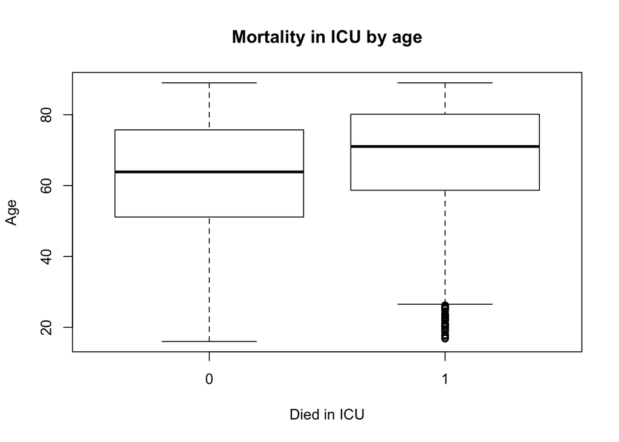

```r
boxplot(NewCohort_static$age.x ~ NewCohort_static$death_icu,
        ylab = "Age", xlab="Died in ICU", main="Mortality in ICU by age")
```

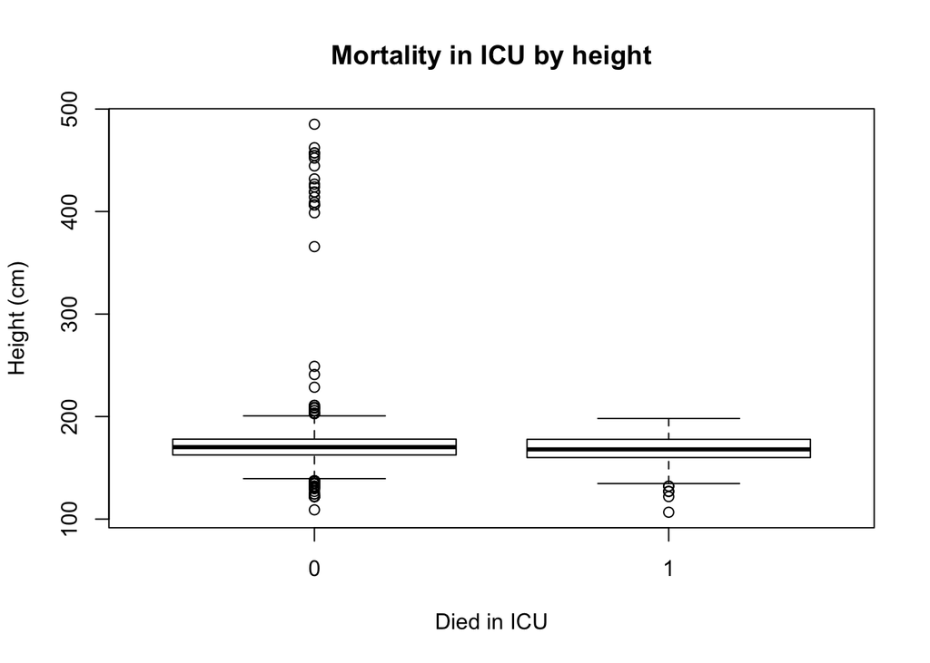

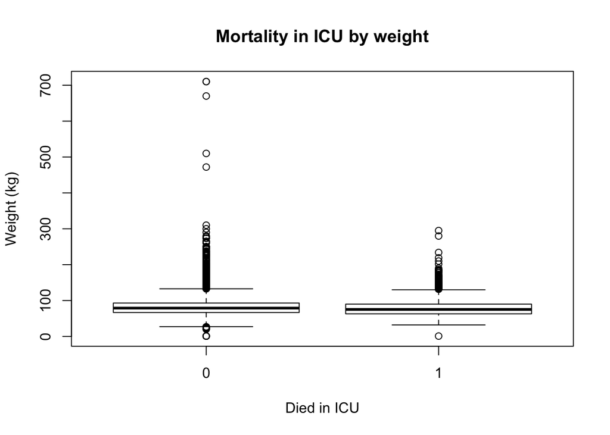

```r
boxplot(NewCohort_static$height ~ NewCohort_static$death_icu,
        ylab = "Height (cm)", xlab="Died in ICU", main="Mortality in ICU by height")
boxplot(NewCohort_static$weight ~ NewCohort_static$death_icu,
        ylab = "Weight (kg)", xlab="Died in ICU", main="Mortality in ICU by weight")
```

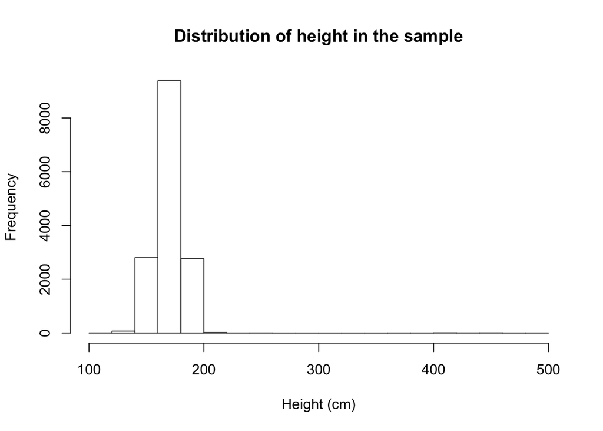

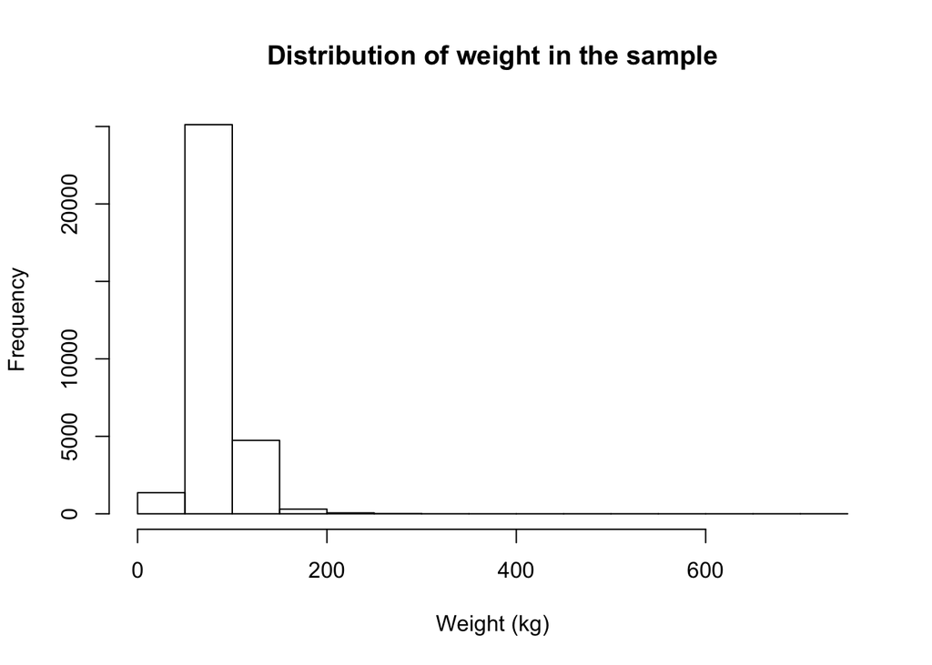

```r
hist(NewCohort_static$height,
        xlab="Height (cm)", main="Distribution of height in the sample")
hist(NewCohort_static$weight,
        xlab="Weight (kg)", main="Distribution of weight in the sample")
```

```r
# To check if the patients with outliers overlap:
# nrow(NewCohort_static[(height > 300 & weight > 300),])
# Set the height as missing and BMI as missing for the outliers in height
summary(NewCohort_static$height)
```

```
##    Min. 1st Qu.  Median    Mean 3rd Qu.    Max.    NA's
##   106.7   162.6   170.2   170.4   178.0   485.1   21143
```

```r
NewCohort_static[height > 300, `:=` (height= "NA", bmi="NA")]
summary(NewCohort_static$weight)
```

```
##    Min. 1st Qu.  Median    Mean 3rd Qu.    Max.    NA's
##    1.00   66.40   79.00   81.66   93.00  710.40    4605
```

```r
NewCohort_static[weight > 300, `:=` (weight= "NA", bmi="NA")]
summary(NewCohort_static$height)
```

```
##    Min. 1st Qu.  Median    Mean 3rd Qu.    Max.    NA's
##   106.7   162.6   170.2   170.1   178.0   249.0   21162
```

```r
summary(NewCohort_static$weight)
```

```
##    Min. 1st Qu.  Median    Mean 3rd Qu.    Max.    NA's
##    1.00   66.40   79.00   81.57   93.00  300.00    4611
```

nrow(NewCohort_static[(height > 300 & weight > 300),])

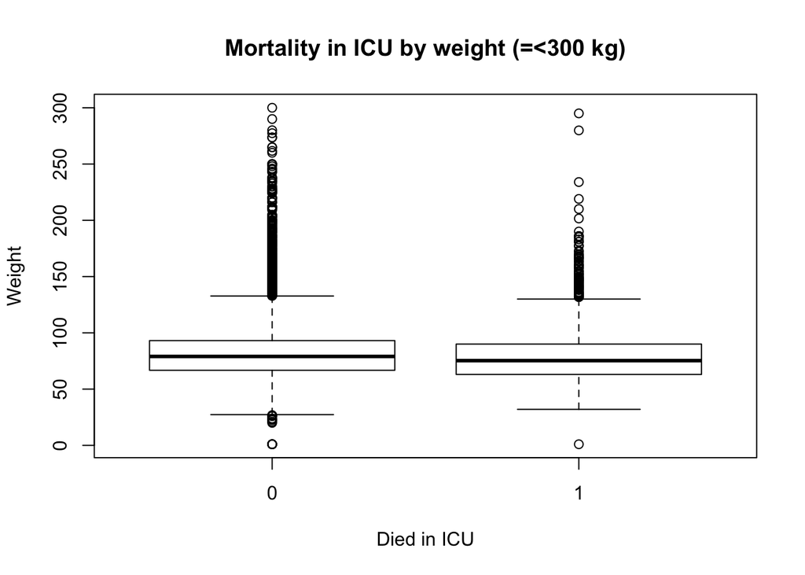

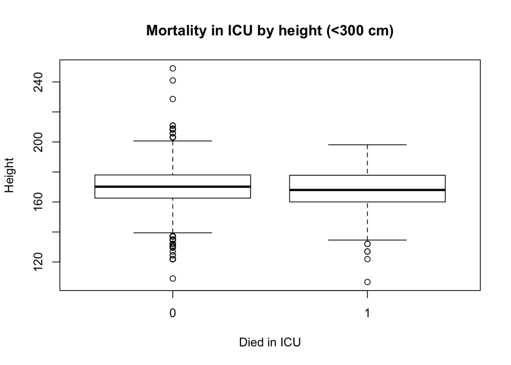

```r
#summary(NewCohort_static$weight)
#nrow(NewCohort_static[weight > 300])
boxplot(NewCohort_static[weight <= 300]$weight ~ NewCohort_static[weight<=300]$death_icu,
        ylab = "Weight", xlab="Died in ICU", main="Mortality in ICU by weight (=<300 kg)")
#summary(NewCohort_static$height)
#nrow(NewCohort_static[height > 300])
boxplot(NewCohort_static[height < 300]$height ~ NewCohort_static[height<300]$death_icu,
        ylab = "Height", xlab="Died in ICU", main="Mortality in ICU by height (<300 cm)")
```

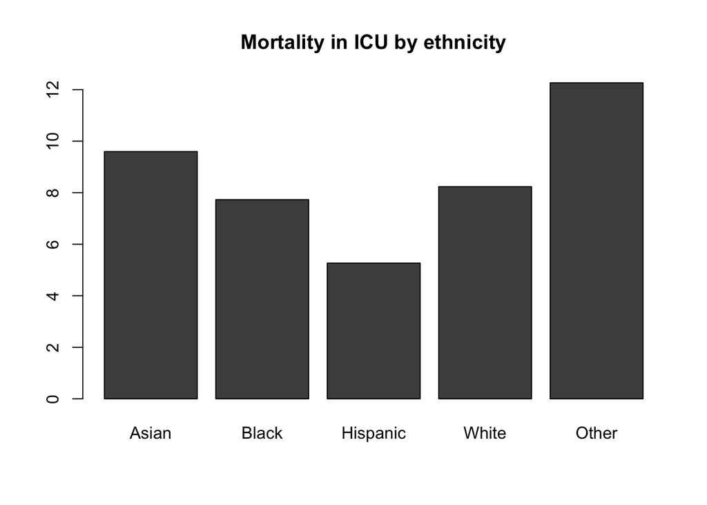

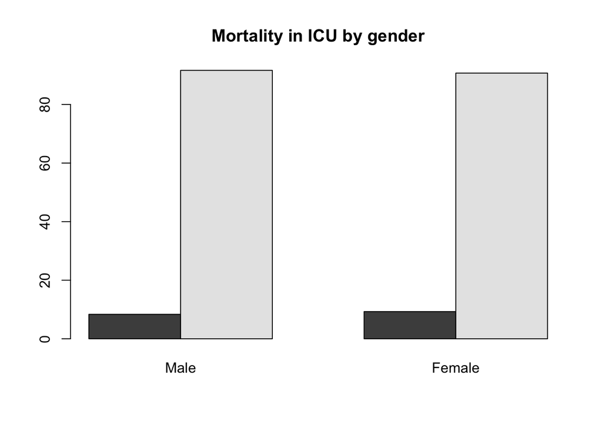

```r
# Ethnicity
barplot(cbind(nrow(NewCohort_static[(death_icu==1 & race_asian==1),])/nrow(NewCohort_static[race_asian==1,])*100,
              nrow(NewCohort_static[(death_icu==1 & race_black==1),])/nrow(NewCohort_static[race_black==1,])*100,
              nrow(NewCohort_static[(death_icu==1 & race_hispanic==1),])/nrow(NewCohort_static[race_hispanic==1,])*100,
              nrow(NewCohort_static[(death_icu==1 & race_asian==0 & race_black==0 & race_hispanic==0 & race_other==0),])/nrow(NewCohort_static[(race_asian==0 & race_black==0 & race_hispanic==0 & race_other==0),])*100,
              nrow(NewCohort_static[(death_icu==1 & race_other==1),])/nrow(NewCohort_static[race_other==1,])*100),
        main="Mortality in ICU by ethnicity", names.arg = c("Asian", "Black", "Hispanic", "White", "Other"))

# Gender
male_stats <- c(nrow(NewCohort_static[(death_icu==1 & is_male==1),])/nrow(NewCohort_static[is_male==1,])*100,
                       nrow(NewCohort_static[(death_icu==0 & is_male==1),])/nrow(NewCohort_static[is_male==1,])*100)

female_stats <- c(nrow(NewCohort_static[(death_icu==1 & is_male==0),])/nrow(NewCohort_static[is_male==0,])*100,
                       nrow(NewCohort_static[(death_icu==0 & is_male==0),])/nrow(NewCohort_static[is_male==0,])*100)

barplot(cbind(male_stats, female_stats), beside = TRUE, main="Mortality in ICU by gender", names.arg = c("Male", "Female"))
```

## Categorisation of variables

- **Body Mass Index (BMI)**. Participants were categorised as being underweight (<18.5), healthy weight (18.5-24.9), overweight (25-29.9) and obese (>30), according to the [NHS guidelines](https://www.nhs.uk/chq/Pages/3215.aspx).
- **Services**: Services whose admissions in the full cohort are < 5% were groupped as `service_other`.

```r
# BMI -all
nrow(NewCohort_static[bmi<18.5])
nrow(NewCohort_static[bmi<18.5])/nrow(NewCohort_static)*100
nrow(NewCohort_static[bmi<18.5])/nrow(NewCohort_static[(!is.na(bmi)),])*100
nrow(NewCohort_static[bmi>=18.5 & bmi<=25])
nrow(NewCohort_static[bmi>=18.5 & bmi<=25])/nrow(NewCohort_static)*100
nrow(NewCohort_static[bmi>=18.5 & bmi<=25])/nrow(NewCohort_static[(!is.na(bmi)),])*100
nrow(NewCohort_static[bmi>25 & bmi<=30])
nrow(NewCohort_static[bmi>25 & bmi<=30])/nrow(NewCohort_static)*100
nrow(NewCohort_static[bmi>25 & bmi<=30])/nrow(NewCohort_static[(!is.na(bmi)),])*100
nrow(NewCohort_static[bmi>30])
nrow(NewCohort_static[bmi>30])/nrow(NewCohort_static)*100
nrow(NewCohort_static[bmi>30])/nrow(NewCohort_static[(!is.na(bmi)),])*100
# Missing
nrow(NewCohort_static[is.na(bmi)])/nrow(NewCohort_static)*100
nrow(NewCohort_static[is.na(bmi)])
#Create the new variable
NewCohort_static[bmi<18.5, bmi_underweight:=1]
NewCohort_static[bmi>=18.5 & bmi<=25, bmi_healthy:=1]
NewCohort_static[bmi>25 & bmi<=30, bmi_overweight:=1]
NewCohort_static[bmi>30, bmi_obese:=1]
NewCohort_static[is.na(bmi), bmi_missing:=1]

#BMI - dead
nrow(NewCohort_static[(death_icu==1 & bmi_underweight==1),])
nrow(NewCohort_static[(death_icu==1 & bmi_underweight==1),])/nrow(NewCohort_static[bmi_underweight==1,])*100
nrow(NewCohort_static[(death_icu==0 & bmi_underweight==1),])
nrow(NewCohort_static[(death_icu==0 & bmi_underweight==1),])/nrow(NewCohort_static[bmi_underweight==1,])*100

nrow(NewCohort_static[(death_icu==1 & bmi_healthy==1),])
nrow(NewCohort_static[(death_icu==1 & bmi_healthy==1),])/nrow(NewCohort_static[bmi_healthy==1,])*100
nrow(NewCohort_static[(death_icu==0 & bmi_healthy==1),])
nrow(NewCohort_static[(death_icu==0 & bmi_healthy==1),])/nrow(NewCohort_static[bmi_healthy==1,])*100

nrow(NewCohort_static[(death_icu==1 & bmi_overweight==1),])
nrow(NewCohort_static[(death_icu==1 & bmi_overweight==1),])/nrow(NewCohort_static[bmi_overweight==1,])*100
nrow(NewCohort_static[(death_icu==0 & bmi_overweight==1),])
nrow(NewCohort_static[(death_icu==0 & bmi_overweight==1),])/nrow(NewCohort_static[bmi_overweight==1,])*100

nrow(NewCohort_static[(death_icu==1 & bmi_obese==1),])
nrow(NewCohort_static[(death_icu==1 & bmi_obese==1),])/nrow(NewCohort_static[bmi_obese==1,])*100
nrow(NewCohort_static[(death_icu==0 & bmi_obese==1),])
nrow(NewCohort_static[(death_icu==0 & bmi_obese==1),])/nrow(NewCohort_static[bmi_obese==1,])*100

nrow(NewCohort_static[(death_icu==1 & bmi_missing==1),])
nrow(NewCohort_static[(death_icu==1 & bmi_missing==1),])/nrow(NewCohort_static[bmi_missing==1,])*100
nrow(NewCohort_static[(death_icu==0 & bmi_missing==1),])
nrow(NewCohort_static[(death_icu==0 & bmi_missing==1),])/nrow(NewCohort_static[bmi_missing==1,])*100

#New bmi category
NewCohort_static[bmi_underweight==1, bmi_cat:= "Underweight"]
NewCohort_static[bmi_healthy==1, bmi_cat:= "Healthy"]
NewCohort_static[bmi_overweight==1, bmi_cat:= "Overweight"]
NewCohort_static[bmi_obese==1, bmi_cat:= "Obese"]
NewCohort_static[bmi_missing==1, bmi_cat:= "Missing"]

# Services
NewCohort_static[service_omed==1 | service_tsurg==1 | service_vsurg==1| service_ortho==1| service_psurg==1| service_gu==1| service_gyn==1| service_ent==1, service_other:=1]
nrow(NewCohort_static[(service_other==1),])/nrow(NewCohort_static)*100
nrow(NewCohort_static[(death_icu==1 & service_other==1),])/nrow(NewCohort_static[service_other==1,])*100
nrow(NewCohort_static[(death_icu==0 & service_other==1),])/nrow(NewCohort_static[service_other==1,])*100

# New Service category
NewCohort_static[service_med==1, service_cat:= "Med"]
NewCohort_static[service_cmed==1, service_cat:= "Cmed"]
NewCohort_static[service_nmed==1, service_cat:= "Nmed"]
NewCohort_static[service_nsurg==1, service_cat:= "Nsurg"]
NewCohort_static[service_csurg==1, service_cat:= "Csurg"]
NewCohort_static[service_surg==1, service_cat:= "Surg"]
NewCohort_static[service_traum==1, service_cat:= "Traum"]
NewCohort_static[service_other==1, service_cat:= "Other"]
```

|  | All (n=36198) | Died in ICU (n=3168) | Did not die in ICU (n=33030) |
| --- | --- | --- | --- |
| **BMI** (%full sample, %withoutNAs) |  |  |  |
| Underweight | 410 (1.1%, 2.7% ) | 34 (8.3%) | 376 (91.7%) |
| Healthy weight | 4458 (12.3%, 29.7% ) | 389 (8.7%) | 4069 (91.3%) |
| Overweight | 5253 (14.5%, 35.0%) | 354 (6.7%) | 4899 (93.3%) |
| Obese | 4882 (13.5%, 32.5%) | 326 (6.7%) | 4556 (93.3%) |
| Missing | 21195 (58.6%,-) | 2065 (9.7%) | 19130 (90.3%) |
| **Service (Groups)** |  |  |  |
| Medical - general service for internal medicine (% admissions) | 36.0% | 11.7% | 88.3% |
| Cardiac Medical- for non-surgical cardiac related admissions (% admissions) | 16.0% | 6.5% | 93.5% |
| Neurologic Medical - non-surgical, relating to the brain (% admissions) | 5.0% | 13.5% | 86.5% |
| Neurologic Surgical - surgical, relating to the brain (% admissions) | 7.2% | 8.8% | 91.2% |
| Cardiac Surgery - for surgical cardiac admissions (% admissions) | 11.7% | 1.9% | 98.1% |
| Surgical - general surgical service not classified elsewhere (% admissions) | 7.5% | 7.9% | 92.1% |
| Trauma - injury or damage caused by physical harm from an external source (% admissions) | 7.3% | 7.5% | 92.5% |
| Other (%admissions) | 9.2% | 9.3% | 90.7% |

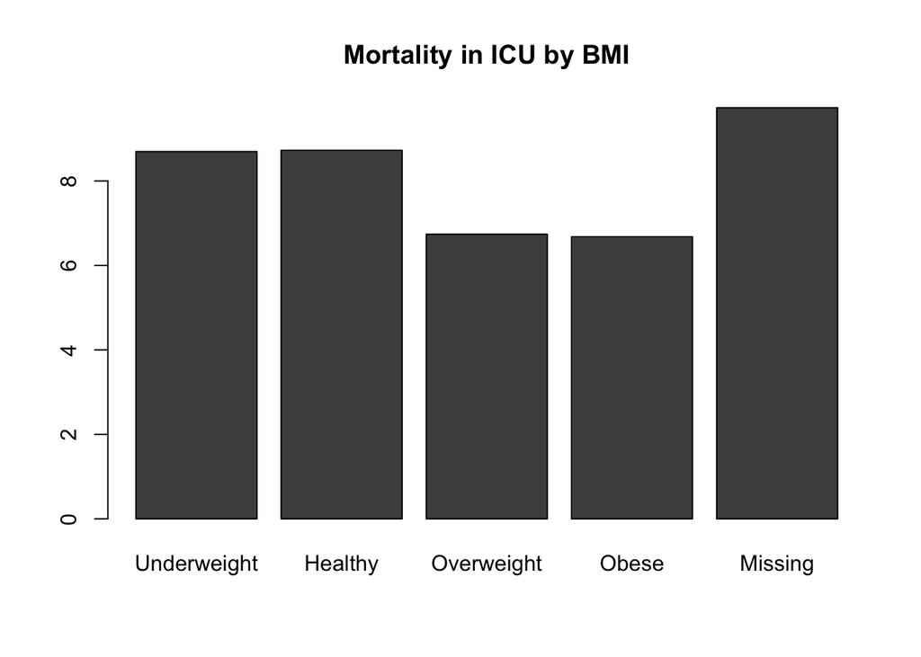

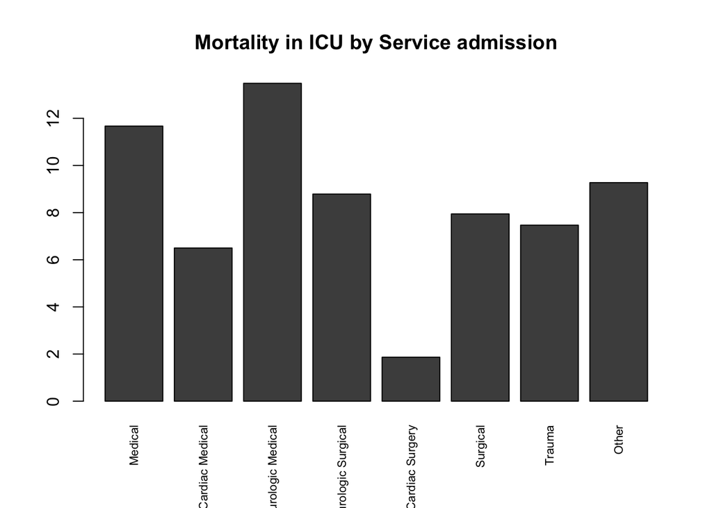

```r
# BMI
barplot(cbind(nrow(NewCohort_static[(death_icu==1 & bmi_underweight==1),])/nrow(NewCohort_static[bmi_underweight==1,])*100,
              nrow(NewCohort_static[(death_icu==1 & bmi_healthy==1),])/nrow(NewCohort_static[bmi_healthy==1,])*100,
              nrow(NewCohort_static[(death_icu==1 & bmi_overweight==1),])/nrow(NewCohort_static[bmi_overweight==1,])*100,
              nrow(NewCohort_static[(death_icu==1 & bmi_obese==1),])/nrow(NewCohort_static[bmi_obese==1,])*100,
              nrow(NewCohort_static[(death_icu==1 & bmi_missing==1),])/nrow(NewCohort_static[bmi_missing==1,])*100),
        main="Mortality in ICU by BMI", names.arg = c("Underweight", "Healthy", "Overweight", "Obese", "Missing"))

# Services
barplot(cbind(nrow(NewCohort_static[(death_icu==1 & service_med==1),])/nrow(NewCohort_static[service_med==1,])*100,
              nrow(NewCohort_static[(death_icu==1 & service_cmed==1),])/nrow(NewCohort_static[service_cmed==1,])*100,
              nrow(NewCohort_static[(death_icu==1 & service_nmed==1),])/nrow(NewCohort_static[service_nmed==1,])*100,
              nrow(NewCohort_static[(death_icu==1 & service_nsurg==1),])/nrow(NewCohort_static[service_nsurg==1,])*100,
              nrow(NewCohort_static[(death_icu==1 & service_csurg==1),])/nrow(NewCohort_static[service_csurg==1,])*100,
              nrow(NewCohort_static[(death_icu==1 & service_surg==1),])/nrow(NewCohort_static[service_surg==1,])*100,
              nrow(NewCohort_static[(death_icu==1 & service_traum==1),])/nrow(NewCohort_static[service_traum==1,])*100,
              nrow(NewCohort_static[(death_icu==1 & service_other==1),])/nrow(NewCohort_static[service_other==1,])*100),
        main="Mortality in ICU by Service admission",
        names.arg = c("Medical", "Cardiac Medical", "Neurologic Medical", "Neurologic Surgical", "Cardiac Surgery", "Surgical", "Trauma", "Other"), cex.names = 0.7, las = 3)
```

## Preliminary analysis

To evaluate the independance between the static variables and mortality, **Pearson’s chi-squared test** was used. The chi-squared test is used to determine whether there is a significant difference between the expected frequencies and the observed frequencies in one or more categories. This test of independence assesses whether unpaired observations on two variables, expressed in a **contingency table**, are independent of each other.

- **Ethnicity vs mortality**. Test the hypothesis whether the ethnicity is independent of mortality at 0.05 significance level. As the p-value is < 2.2e-16, there was enough evidence to reject the null hypothesis that ethnicity was independent of mortality. In other words, the chi-squared result gave reasonable evidence to suggest an association between ethnicity and mortality.

```r
# Table function to tally ethnicity and mortality
tb1 <- table(NewCohort_static$race_cat, NewCohort_static$death_icu)
chisq.test(tb1)
```

- **BMI vs Mortality**. As the p-value of the Chi-squared test is = 2.662e-16, there was enough evidence to reject the null hypothesis that BMI category was independent of mortality.

```r
tb2 <- table(NewCohort_static$bmi_cat, NewCohort_static$death_icu)
chisq.test(tb2)
```

```r
tb3 <- table(NewCohort_static$gender, NewCohort_static$death_icu)
chisq.test(tb3)
```

- **Service vs Mortality**. As the p-value is < 2.2e-16, there was strong evidence to suggest an association between the service of admission and mortality.

```r
tb4 <- table(NewCohort_static$service_cat, NewCohort_static$death_icu)
chisq.test(tb4)
```

[output not shown]

## Further analysis: BMI **Missing** Category

```r
NewCohort_static[bmi_underweight==1, bmi_mis:= "0"]
NewCohort_static[bmi_healthy==1, bmi_mis:= "0"]
NewCohort_static[bmi_overweight==1, bmi_mis:= "0"]
NewCohort_static[bmi_obese==1, bmi_mis:= "0"]
NewCohort_static[bmi_missing==1, bmi_mis:= "1"]
```

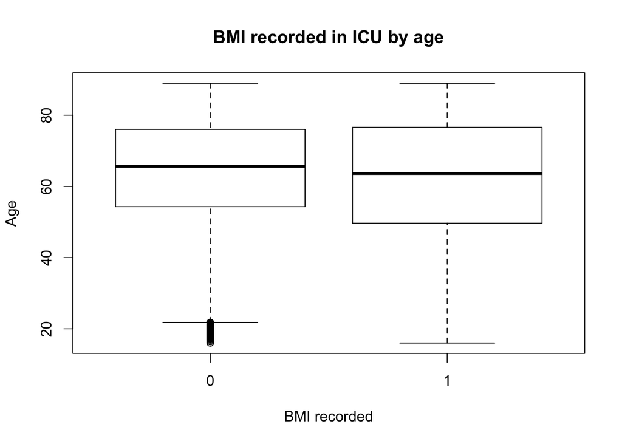

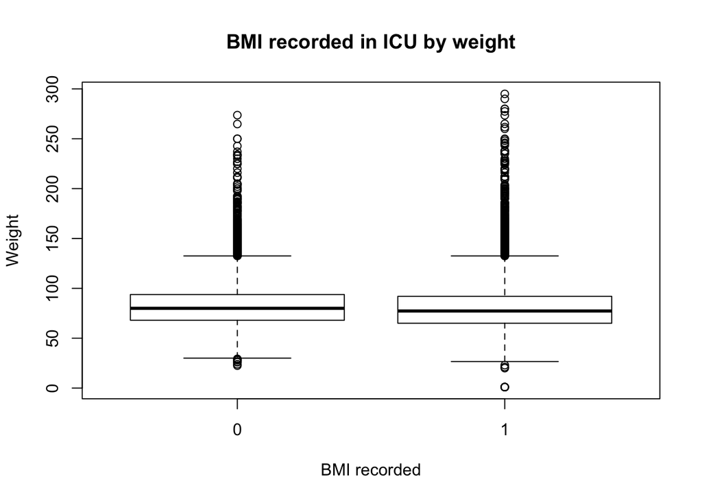

```r
boxplot(NewCohort_static$age.x ~ NewCohort_static$bmi_mis,
        ylab = "Age", xlab="BMI recorded", main="BMI recorded in ICU by age")

boxplot(NewCohort_static[weight<300]$weight ~ NewCohort_static[weight<300]$bmi_mis,
        ylab = "Weight", xlab="BMI recorded", main="BMI recorded in ICU by weight")
```

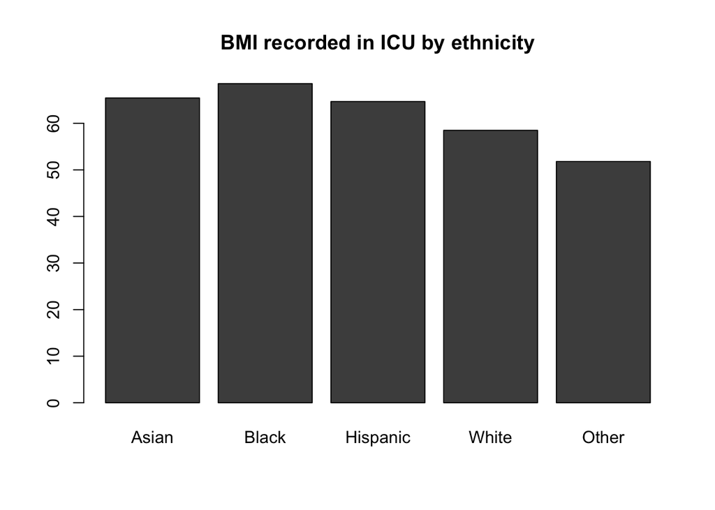

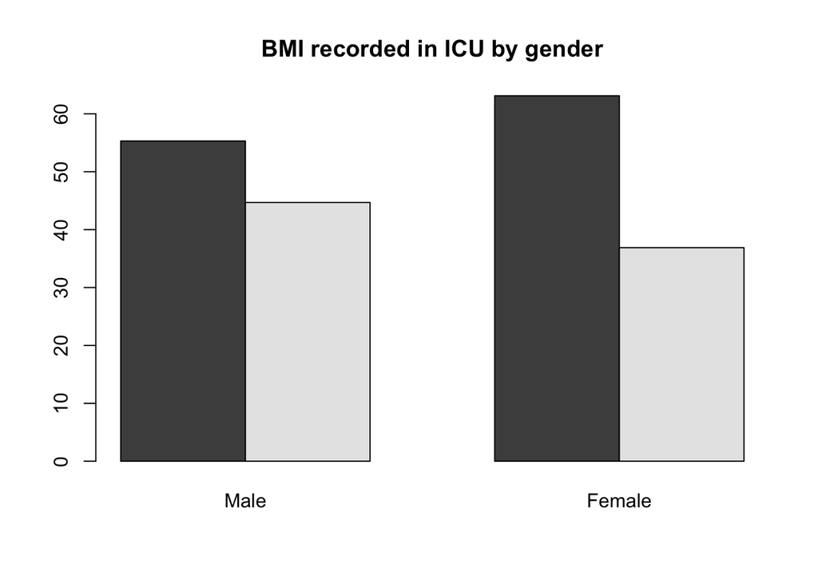

```r
# Ethnicity
barplot(cbind(nrow(NewCohort_static[(bmi_mis==1 & race_asian==1),])/nrow(NewCohort_static[race_asian==1,])*100,
              nrow(NewCohort_static[(bmi_mis==1 & race_black==1),])/nrow(NewCohort_static[race_black==1,])*100,
              nrow(NewCohort_static[(bmi_mis==1 & race_hispanic==1),])/nrow(NewCohort_static[race_hispanic==1,])*100,
              nrow(NewCohort_static[(bmi_mis==1 & race_asian==0 & race_black==0 & race_hispanic==0 & race_other==0),])/nrow(NewCohort_static[(race_asian==0 & race_black==0 & race_hispanic==0 & race_other==0),])*100,
              nrow(NewCohort_static[(bmi_mis==1 & race_other==1),])/nrow(NewCohort_static[race_other==1,])*100),
        main="BMI recorded in ICU by ethnicity", names.arg = c("Asian", "Black", "Hispanic", "White", "Other"))

# Gender
male_stats <- c(nrow(NewCohort_static[(bmi_mis==1 & is_male==1),])/nrow(NewCohort_static[is_male==1,])*100,
                       nrow(NewCohort_static[(bmi_mis==0 & is_male==1),])/nrow(NewCohort_static[is_male==1,])*100)

female_stats <- c(nrow(NewCohort_static[(bmi_mis==1 & is_male==0),])/nrow(NewCohort_static[is_male==0,])*100,
                       nrow(NewCohort_static[(bmi_mis==0 & is_male==0),])/nrow(NewCohort_static[is_male==0,])*100)

barplot(cbind(male_stats, female_stats), beside = TRUE, main="BMI recorded in ICU by gender", names.arg = c("Male", "Female"))
```

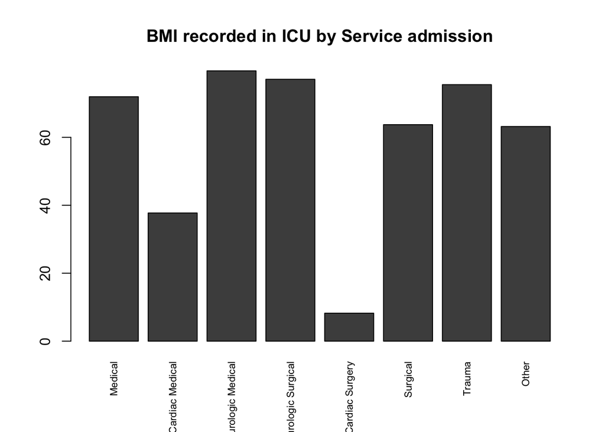

```r
# Services
barplot(cbind(nrow(NewCohort_static[(bmi_mis==1 & service_med==1),])/nrow(NewCohort_static[service_med==1,])*100,
              nrow(NewCohort_static[(bmi_mis==1 & service_cmed==1),])/nrow(NewCohort_static[service_cmed==1,])*100,
              nrow(NewCohort_static[(bmi_mis==1 & service_nmed==1),])/nrow(NewCohort_static[service_nmed==1,])*100,
              nrow(NewCohort_static[(bmi_mis==1 & service_nsurg==1),])/nrow(NewCohort_static[service_nsurg==1,])*100,
              nrow(NewCohort_static[(bmi_mis==1 & service_csurg==1),])/nrow(NewCohort_static[service_csurg==1,])*100,
              nrow(NewCohort_static[(bmi_mis==1 & service_surg==1),])/nrow(NewCohort_static[service_surg==1,])*100,
              nrow(NewCohort_static[(bmi_mis==1 & service_traum==1),])/nrow(NewCohort_static[service_traum==1,])*100,
              nrow(NewCohort_static[(bmi_mis==1 & service_other==1),])/nrow(NewCohort_static[service_other==1,])*100),
        main="BMI recorded in ICU by Service admission",
        names.arg = c("Medical", "Cardiac Medical", "Neurologic Medical", "Neurologic Surgical", "Cardiac Surgery", "Surgical", "Trauma", "Other"), cex.names = 0.7, las = 3)
```

It can be seen than the BMI likely to be recorded in the cardiac surgery unit compared to the other ones. This correlates with the mortality, since patients admitted to cardiac surgery are less likely to die in ICU.

- **Ethnicity vs BMI recorded**. Test the hypothesis whether the ethnicity is independent of mortality at 0.05 significance level. As the p-value is < 2.2e-16, there was enough evidence to reject the null hypothesis that ethnicity was independent of mortality. In other words, the chi-squared result gave reasonable evidence to suggest an association between ethnicity and mortality.

```r
# Table function to tally ethnicity and mortality
tb5 <- table(NewCohort_static$race_cat, NewCohort_static$bmi_mis)
chisq.test(tb5)
```

```r
tb6 <- table(NewCohort_static$gender, NewCohort_static$bmi_mis)
chisq.test(tb6)
```

- **Service vs BMI recorded**. As the p-value is < 2.2e-16, there was strong evidence to suggest an association between the service of admission and mortality.

```r
tb6 <- table(NewCohort_static$service_cat, NewCohort_static$bmi_mis)
tb6
chisq.test(tb6)
```

## Additional information

```r
save(NewCohort_static,
     file = "/Users/maria/OneDrive - University College London/BHF-PhD/Rotation-2/MIMIC-III/Data/NewCohort_static.Rda")
```